# Praca domowa 2

Wioletta Rapacz

## Dane

Dane wykorzystane w Pracy domowej 2 dotyczą wyników egzaminów z 3 umiejętności: czytania, pisania i operacji matematycznych. Dodatkowo dostępne są podstawowe informacje o studentach i ich rodzicach. Opis wszystkich kolumn znajduje się również w pliku `README.md`.

| Zmienna | Opis |
| --- | --- |
| **gender** | płeć |
| **race.ethnicity** | pochodzenie etniczne |
| **parental.level.of.education** | wykształcenie rodziców |
| **lunch** | jaki obiad jedli uczniowie w dniu egzaminu |
| **test.preparation.course** | czy uczeń odbył kurs przygotowujący |
| **math.score** | wynik egzaminu z matematyki |
| **reading.score** | wynik egzaminu z czytania |
| **writing.score** | wynik egzaminu z pisania |

## Zadanie 1

Jak wyglądają rozkłady wyników uczniów z trzech przedmiotów (matematyka, czytanie, pisanie)?

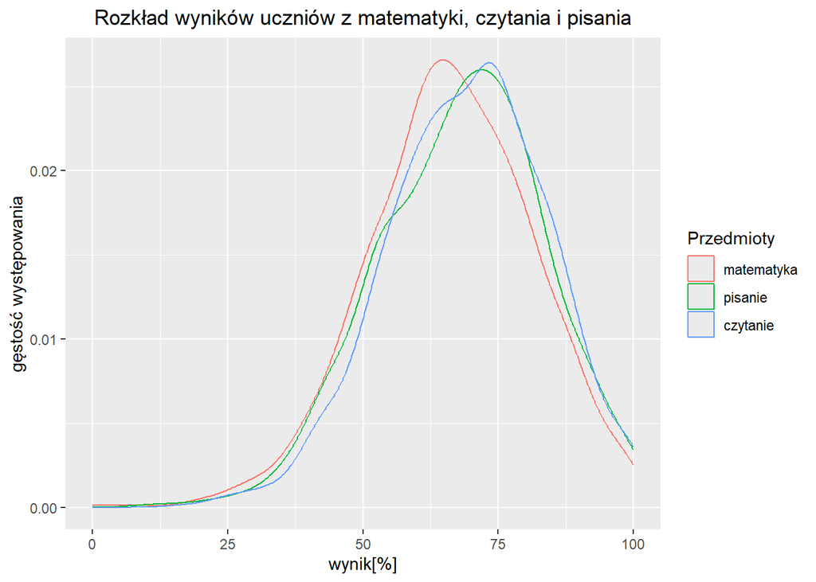

```r
#score <- pivot_longer(df,cols=ends_with(".score"), names_to="przedmiot", #values_to="wynik")
dane1 <- stack(df,select=c(math.score,writing.score,reading.score))
#czy można używać tidyr???
dane1 %>%
  ggplot(aes(x=values, color=ind))+
  geom_density()+
  labs(title="Rozkład wyników uczniów z matematyki, czytania i pisania", x="wynik[%]", y="gęstość występowania", color="Przedmioty")+
  scale_color_discrete(labels=c("math.score" = "matematyka",
               "reading.score" = "czytanie",
               "writing.score" = "pisanie"))+
  theme( plot.title = element_text(hjust=0.5))
```

**Komentarz:** Na wykresie widać, że punkt dla którego funkcja gęstości osiąga maksimum jest przesunięty dla egzaminu z matematyki w lewo w stosunku do dwóch pozostałych egzaminów, czyli najczęstszy wynik z matematyki był średnio gorszy niż z czytania i pisania.

## Zadanie 2

Czy istnieje zauważalna różnica w wynikach między uczniami i uczennicami?

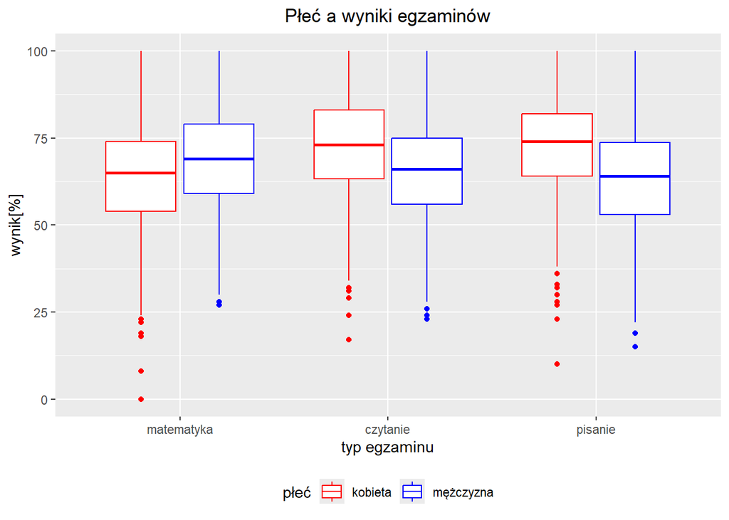

```r
dane2 <- df %>%
  pivot_longer(cols=ends_with("score"),names_to="egzaminy", values_to="wynik")

dane2 %>%
  ggplot(aes(y=wynik,color=gender, x =  egzaminy))+
  geom_boxplot()+
  labs(title="Płeć a wyniki egzaminów",x="typ egzaminu", y="wynik[%]", color="płeć")+
    scale_color_manual(labels=c("female" = "kobieta",
               "male" = "mężczyzna"),values = c( "male"="blue", "female"="red"))+
  theme(legend.position = "bottom", plot.title = element_text(hjust=0.5))+
     scale_x_discrete(labels = c(
    "math.score" = "matematyka",
    "reading.score" = "czytanie",
    "writing.score" = "pisanie"
  ))
```

**Komentarz:** Istnieje zauważalna różnica w wynikach uczniów i ucznnic. Jak widać na wykresach IQR wyników uczennic z czytania i pisania plasuje się wyżej niż uczniów, skąd można wysnuć wniosek, że większość uczennic uzyskało lepszy wynik niż większość uczniów. Odwrotnie jest z wynikami z matematyki, gdzie to uczniowie osiągali często lepsze wyniki.

## Zadanie 3

Czy uczniowie, którzy ukończyli kurs przygotowawczy, osiągają lepsze wyniki niż pozostali?

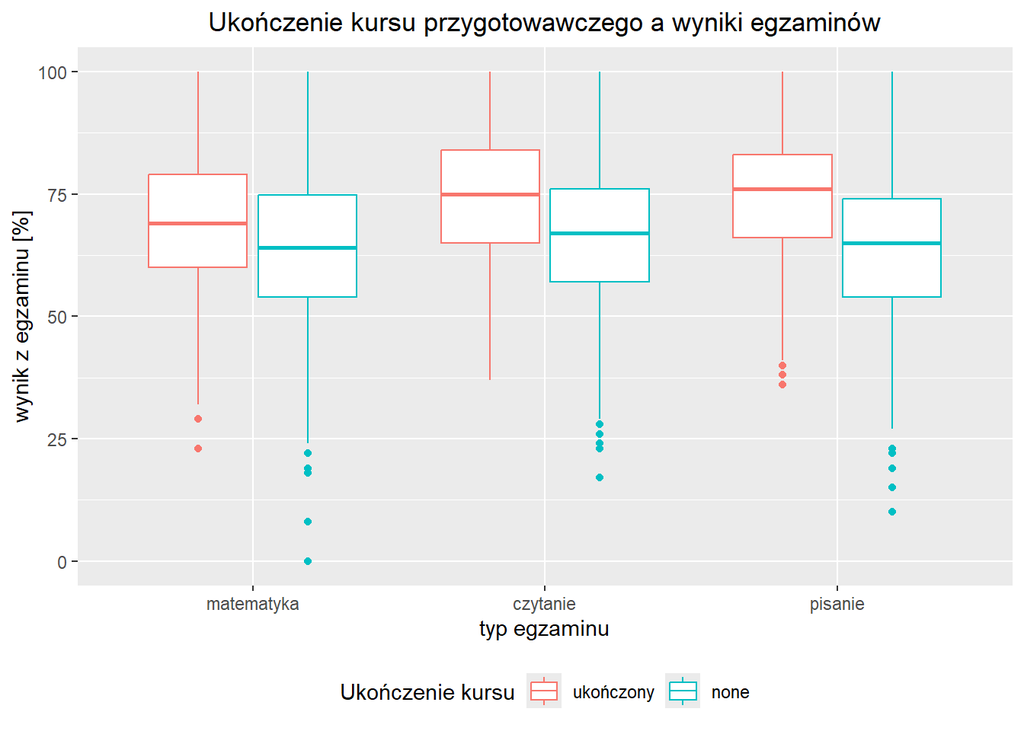

```r
dane3 <- df %>%
  pivot_longer(cols=ends_with("score"),names_to="egzaminy", values_to="wynik")
dane3 %>%
  ggplot(aes(y=wynik,color=test.preparation.course, x =  egzaminy))+
  geom_boxplot()+
  labs(title="Ukończenie kursu przygotowawczego a wyniki egzaminów",x="typ egzaminu", y="wynik z egzaminu [%]", color="Ukończenie kursu")+
    scale_color_discrete(labels=c("completed" = "ukończony",
               "none" = "none"))+
 theme(legend.position = "bottom", plot.title = element_text(hjust=0.5))+
       scale_x_discrete(labels = c(
    "math.score" = "matematyka",
    "reading.score" = "czytanie",
    "writing.score" = "pisanie"
  ))
```

**Komentarz:** We wszystkich typach egzaminów istnieje zauważalna różnica między rozkładem wyników uczniów, którzy ukończyli kurs przygotowawczy. Mediana ich wyników jest większa, jednocześnie nie ma wiele wartości skrajnych, skąd można wysnuć wniosek, że większość z nich osiągneła lepszy wynik niż większość uczniów, którzy nie ukończyli kursów.